# GLMM practical with R

Binomial and Poisson mixed models

O Rodriguez de Rivera Ortega, PhD

University of Exeter

# Practical overview

## Learning outcomes

By the end of this practical, students should be able to:

- fit binomial and Poisson GLMMs using `glmer()`;
- interpret coefficients on the link and response scales;
- compare nested GLMMs using likelihood-ratio tests;
- assess overdispersion in GLMMs;
- visualise population-level predictions;
- recognise when a negative-binomial or zero-inflated model may be needed.

## Practical workflow

For each example we will:

1. inspect the data structure;
2. plot the response by group and key predictors;
3. fit a baseline model;
4. add fixed effects and random effects;
5. interpret the fitted model;
6. check diagnostics and overdispersion;
7. produce predictions on the response scale.

# Setup

## Packages

```r
install.packages(c(
  "tidyverse", "lme4", "ggeffects", "broom.mixed",
  "performance", "DHARMa", "glmmTMB"
))
```

```r
library(tidyverse)
library(lme4)
library(ggeffects)

theme_set(theme_minimal(base_size = 12))
```

## Helper: overdispersion check

For Poisson and binomial GLMMs, a simple Pearson overdispersion ratio is:

```r
overdisp_fun <- function(model) {
  rdf <- df.residual(model)
  pearson_resid <- residuals(model, type = "pearson")
  pearson_chisq <- sum(pearson_resid^2)
  ratio <- pearson_chisq / rdf
  p_value <- pchisq(pearson_chisq, df = rdf, lower.tail = FALSE)

  tibble(
    chisq = pearson_chisq,
    ratio = ratio,
    residual_df = rdf,
    p_value = p_value
  )
}
```

Rules of thumb:

- ratio close to 1: no obvious overdispersion;
- ratio clearly above 1.2–1.5: investigate;
- ratio much larger than 1: consider missing structure, zero inflation or a different distribution.

# Part 1: Binomial GLMM

## Data: disease incidence in herds

The `cbpp` dataset from `lme4` records the number of new cases of contagious bovine pleuropneumonia in cattle herds over four periods.

```r
data("cbpp", package = "lme4")

cbpp <- cbpp %>%
  mutate(
    herd = factor(herd),
    period = factor(period),
    failures = size - incidence,
    proportion = incidence / size
  )

glimpse(cbpp)
```

```
## Rows: 56
## Columns: 6
## $ herd       <fct> 1, 1, 1, 1, 2, 2, 2, 3, 3, 3, 3, 4, 4, 4, 4, 5, 5, 5, 5, 6,…
## $ incidence  <dbl> 2, 3, 4, 0, 3, 1, 1, 8, 2, 0, 2, 2, 0, 2, 0, 5, 0, 0, 1, 3,…
## $ size       <dbl> 14, 12, 9, 5, 22, 18, 21, 22, 16, 16, 20, 10, 10, 9, 6, 18,…
## $ period     <fct> 1, 2, 3, 4, 1, 2, 3, 1, 2, 3, 4, 1, 2, 3, 4, 1, 2, 3, 4, 1,…
## $ failures   <dbl> 12, 9, 5, 5, 19, 17, 20, 14, 14, 16, 18, 8, 10, 7, 6, 13, 2…
## $ proportion <dbl> 0.14285714, 0.25000000, 0.44444444, 0.00000000, 0.13636364,…
```

## Explore the data

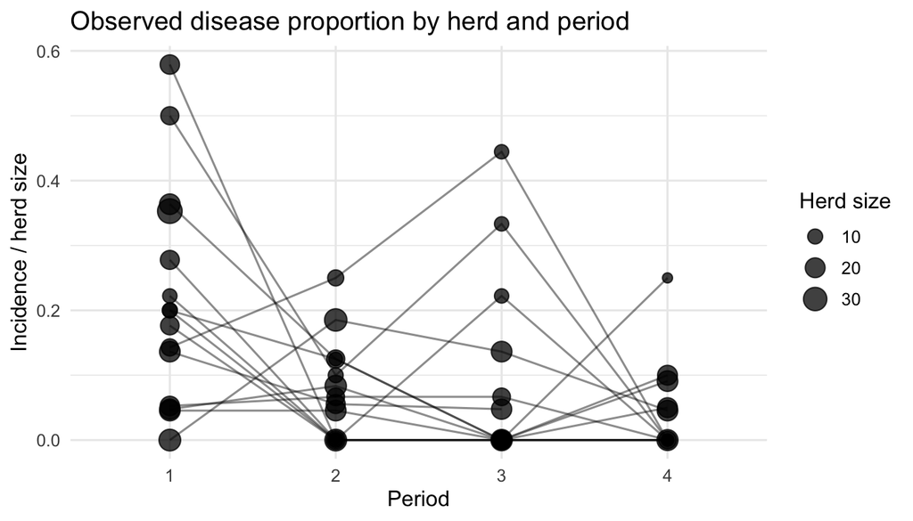

```r
ggplot(cbpp, aes(x = period, y = proportion, group = herd)) +
  geom_line(alpha = 0.45) +
  geom_point(aes(size = size), alpha = 0.75) +
  labs(
    title = "Observed disease proportion by herd and period",
    x = "Period",
    y = "Incidence / herd size",
    size = "Herd size"
  )
```

## Fit a GLM that ignores herd

```r
cbpp_glm <- glm(
  cbind(incidence, failures) ~ period,
  family = binomial,
  data = cbpp
)

summary(cbpp_glm)
```

```
##
## Call:
## glm(formula = cbind(incidence, failures) ~ period, family = binomial,
##     data = cbpp)
##
## Coefficients:
##             Estimate Std. Error z value Pr(>|z|)
## (Intercept)  -1.2690     0.1449  -8.757  < 2e-16 ***
## period2      -1.1708     0.2915  -4.017 5.90e-05 ***
## period3      -1.3014     0.3129  -4.159 3.19e-05 ***
## period4      -1.7823     0.4131  -4.315 1.60e-05 ***
## ---
## Signif. codes:  0 '***' 0.001 '**' 0.01 '*' 0.05 '.' 0.1 ' ' 1
##
## (Dispersion parameter for binomial family taken to be 1)
##
##     Null deviance: 154.82  on 55  degrees of freedom
## Residual deviance: 114.10  on 52  degrees of freedom
## AIC: 206.06
##
## Number of Fisher Scoring iterations: 5
```

This model treats all herd-period observations as independent after accounting for period.

## Fit a random-intercept GLMM

```r
cbpp_glmm <- glmer(
  cbind(incidence, failures) ~ period + (1 | herd),
  family = binomial,
  data = cbpp
)

summary(cbpp_glmm)
```

```
## Generalized linear mixed model fit by maximum likelihood (Laplace
##   Approximation) [glmerMod]
##  Family: binomial  ( logit )
## Formula: cbind(incidence, failures) ~ period + (1 | herd)
##    Data: cbpp
##
##       AIC       BIC    logLik -2*log(L)  df.resid
##     194.1     204.2     -92.0     184.1        51
##
## Scaled residuals:
##     Min      1Q  Median      3Q     Max
## -2.3816 -0.7889 -0.2026  0.5142  2.8791
##
## Random effects:
##  Groups Name        Variance Std.Dev.
##  herd   (Intercept) 0.4123   0.6421
## Number of obs: 56, groups:  herd, 15
##
## Fixed effects:
##             Estimate Std. Error z value Pr(>|z|)
## (Intercept)  -1.3983     0.2312  -6.048 1.47e-09 ***
## period2      -0.9919     0.3032  -3.272 0.001068 **
## period3      -1.1282     0.3228  -3.495 0.000474 ***
## period4      -1.5797     0.4220  -3.743 0.000182 ***
## ---
## Signif. codes:  0 '***' 0.001 '**' 0.01 '*' 0.05 '.' 0.1 ' ' 1
##
## Correlation of Fixed Effects:
##         (Intr) perid2 perid3
## period2 -0.363
## period3 -0.340  0.280
## period4 -0.260  0.213  0.198
```

The random intercept allows baseline disease risk to vary among herds.

## Test the fixed effect of period

```r
cbpp_null <- glmer(
  cbind(incidence, failures) ~ 1 + (1 | herd),
  family = binomial,
  data = cbpp
)

anova(cbpp_null, cbpp_glmm, test = "Chisq")
```

```
## Data: cbpp
## Models:
## cbpp_null: cbind(incidence, failures) ~ 1 + (1 | herd)
## cbpp_glmm: cbind(incidence, failures) ~ period + (1 | herd)
##           npar    AIC    BIC   logLik -2*log(L) Chisq Df Pr(>Chisq)
## cbpp_null    2 213.66 217.71 -104.832    209.66
## cbpp_glmm    5 194.05 204.18  -92.027    184.05 25.61  3  1.151e-05 ***
## ---
## Signif. codes:  0 '***' 0.001 '**' 0.01 '*' 0.05 '.' 0.1 ' ' 1
```

This compares a model with period to a model without period, while keeping the same random-effect structure.

## Interpret fixed effects

```r
fixef(cbpp_glmm)
```

```
## (Intercept)     period2     period3     period4
##   -1.398343   -0.991925   -1.128216   -1.579745
```

```r
exp(fixef(cbpp_glmm))
```

```
## (Intercept)     period2     period3     period4
##   0.2470059   0.3708621   0.3236100   0.2060275
```

Remember:

- coefficients are on the log-odds scale;
- exponentiated coefficients are odds ratios;
- predicted probabilities are usually easier to communicate.

## Population-average predictions

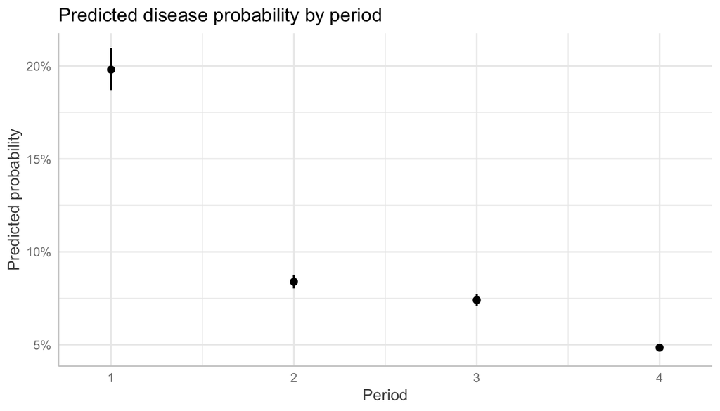

```r
cbpp_pred <- ggpredict(cbpp_glmm, terms = "period", type = "fixed")

plot(cbpp_pred) +
  labs(
    title = "Predicted disease probability by period",
    x = "Period",
    y = "Predicted probability"
  )
```

## Herd-level random effects

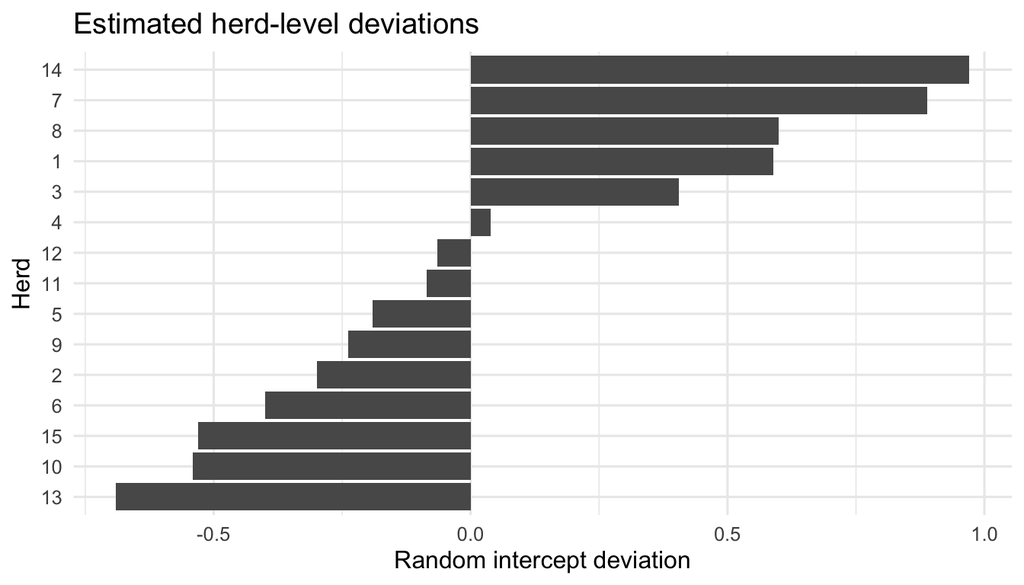

```r
ranef_cbpp <- ranef(cbpp_glmm)$herd %>%
  as.data.frame() %>%
  rownames_to_column("herd") %>%
  rename(random_intercept = `(Intercept)`)

ggplot(ranef_cbpp, aes(x = reorder(herd, random_intercept), y = random_intercept)) +
  geom_col() +
  coord_flip() +
  labs(
    title = "Estimated herd-level deviations",
    x = "Herd",
    y = "Random intercept deviation"
  )
```

Herds with positive random intercepts have higher baseline log-odds than the average herd, after accounting for period.

## Check overdispersion

```r
overdisp_fun(cbpp_glmm)
```

```
## # A tibble: 1 × 4
##   chisq ratio residual_df p_value
##   <dbl> <dbl>       <int>   <dbl>
## 1  63.1  1.24          51   0.120
```

For a more complete diagnostic workflow, simulation-based residual diagnostics are often useful.

```r
if (requireNamespace("DHARMa", quietly = TRUE)) {
  sim_res <- DHARMa::simulateResiduals(cbpp_glmm)
  plot(sim_res)
  DHARMa::testDispersion(sim_res)
  DHARMa::testZeroInflation(sim_res)
}
```

[output not shown]

## Exercise 1

1. Fit a model with `period` as a numeric variable instead of a factor.
2. Compare it with the factor model.
3. Which model would you prefer, and why?
4. Interpret the predicted probabilities.

# Part 2: Poisson GLMM

## Data: ticks on red grouse chicks

The `grouseticks` dataset from `lme4` contains counts of ticks on red grouse chicks. Chicks are grouped within broods, so a mixed model is appropriate.

```r
data("grouseticks", package = "lme4")

ticks <- grouseticks %>%
  drop_na(TICKS, HEIGHT, YEAR, LOCATION, BROOD) %>%
  mutate(
    BROOD = factor(BROOD),
    YEAR = factor(YEAR),
    LOCATION = factor(LOCATION),
    height_scaled = as.numeric(scale(HEIGHT))
  )

glimpse(ticks)
```

```
## Rows: 403
## Columns: 8
## $ INDEX         <fct> 1, 2, 3, 4, 5, 6, 7, 8, 9, 10, 11, 12, 13, 14, 15, 16, 1…
## $ TICKS         <dbl> 0, 0, 0, 0, 0, 3, 2, 0, 0, 2, 0, 0, 0, 0, 0, 0, 0, 0, 0,…
## $ BROOD         <fct> 501, 501, 502, 503, 503, 503, 503, 504, 504, 504, 505, 5…
## $ HEIGHT        <dbl> 465, 465, 472, 475, 475, 475, 475, 488, 488, 488, 492, 4…
## $ YEAR          <fct> 95, 95, 95, 95, 95, 95, 95, 95, 95, 95, 95, 95, 95, 95, …
## $ LOCATION      <fct> 32, 32, 36, 37, 37, 37, 37, 44, 44, 44, 47, 47, 47, 45, …
## $ cHEIGHT       <dbl> 2.759305, 2.759305, 9.759305, 12.759305, 12.759305, 12.7…
## $ height_scaled <dbl> 0.07674010, 0.07674010, 0.27141979, 0.35485394, 0.354853…
```

## Explore the count response

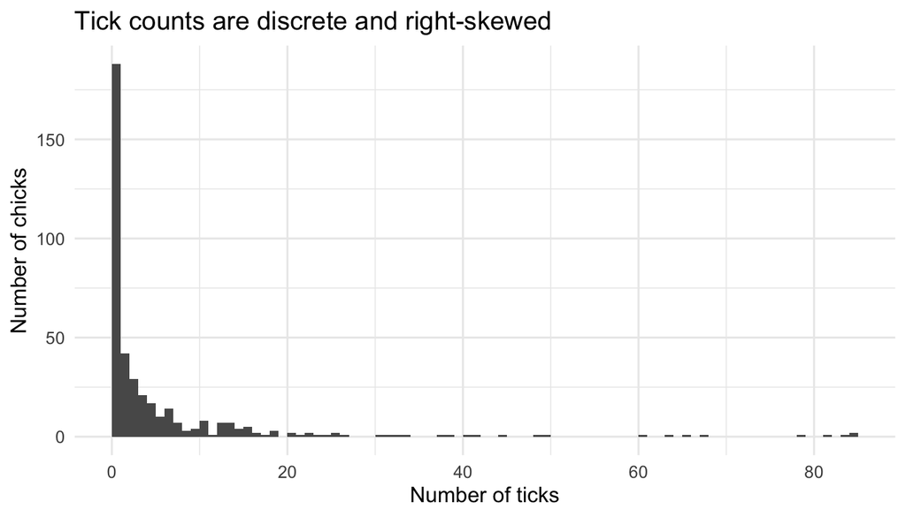

```r
ggplot(ticks, aes(x = TICKS)) +
  geom_histogram(binwidth = 1, boundary = 0) +
  labs(
    title = "Tick counts are discrete and right-skewed",
    x = "Number of ticks",
    y = "Number of chicks"
  )
```

## Counts by brood and height

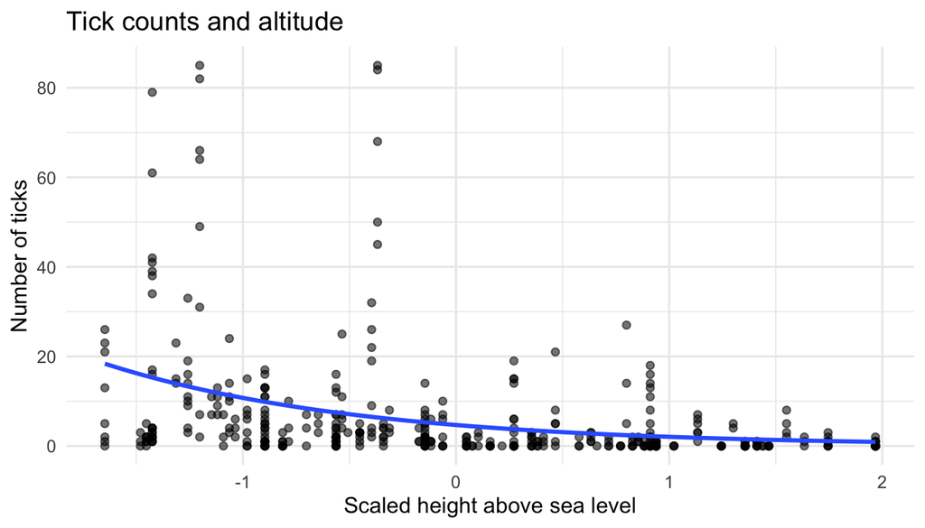

```r
ggplot(ticks, aes(x = height_scaled, y = TICKS)) +
  geom_point(alpha = 0.55) +
  geom_smooth(method = "glm", method.args = list(family = poisson), se = FALSE) +
  labs(
    title = "Tick counts and altitude",
    x = "Scaled height above sea level",
    y = "Number of ticks"
  )
```

## Start with a Poisson GLM

```r
ticks_glm <- glm(
  TICKS ~ height_scaled + YEAR + LOCATION,
  family = poisson,
  data = ticks
)

summary(ticks_glm)
```

```
##
## Call:
## glm(formula = TICKS ~ height_scaled + YEAR + LOCATION, family = poisson,
##     data = ticks)
##
## Coefficients: (1 not defined because of singularities)
##                 Estimate Std. Error z value Pr(>|z|)
## (Intercept)    7.642e-01  2.179e-01   3.508 0.000452 ***
## height_scaled -7.078e-01  1.288e-01  -5.496 3.88e-08 ***
## YEAR96         9.175e-01  8.623e-02  10.641  < 2e-16 ***
## YEAR97        -1.472e+00  1.266e-01 -11.632  < 2e-16 ***
## LOCATION2     -5.209e-02  5.207e-01  -0.100 0.920326
## LOCATION3     -2.091e+00  2.956e-01  -7.073 1.52e-12 ***
## LOCATION4      1.181e+00  1.145e-01  10.314  < 2e-16 ***
## LOCATION5      2.410e-01  1.735e-01   1.389 0.164867
## LOCATION6      9.591e-03  1.400e-01   0.069 0.945386
## LOCATION7      2.261e+00  1.410e-01  16.040  < 2e-16 ***
## LOCATION8     -2.963e-01  2.602e-01  -1.139 0.254836
## LOCATION9      7.462e-01  2.069e-01   3.606 0.000311 ***
## LOCATION10    -4.252e-01  3.520e-01  -1.208 0.227002
## LOCATION11     7.657e-01  1.721e-01   4.451 8.56e-06 ***
## LOCATION12    -1.029e+00  3.113e-01  -3.304 0.000952 ***
## LOCATION13    -2.066e-02  2.038e-01  -0.101 0.919247
## LOCATION14    -2.827e-01  1.505e-01  -1.879 0.060309 .
## LOCATION15    -2.038e-01  4.767e-01  -0.427 0.669017
## LOCATION16     1.762e+00  3.074e-01   5.731 9.96e-09 ***
## LOCATION17     3.822e-02  3.390e-01   0.113 0.910246
## LOCATION18    -5.298e-01  2.972e-01  -1.783 0.074614 .
## LOCATION19     3.369e-01  1.888e-01   1.784 0.074431 .
## LOCATION20     3.004e-01  2.091e-01   1.436 0.150948
## LOCATION21    -9.422e-01  5.992e-01  -1.572 0.115873
## LOCATION22     6.951e-01  2.814e-01   2.470 0.013493 *
## LOCATION23     7.207e-01  1.950e-01   3.695 0.000220 ***
## LOCATION24     2.253e+00  1.830e-01  12.311  < 2e-16 ***
## LOCATION25     1.412e+00  3.099e-01   4.555 5.23e-06 ***
## LOCATION26     6.240e-01  3.189e-01   1.957 0.050362 .
## LOCATION27    -1.111e+00  4.526e-01  -2.455 0.014070 *
## LOCATION28     3.572e-01  2.325e-01   1.537 0.124396
## LOCATION29    -1.177e+00  3.896e-01  -3.022 0.002508 **
## LOCATION30     1.917e-01  2.872e-01   0.667 0.504511
```

[output cut: 28 more lines]

```
## LOCATION59    -1.603e+01  1.052e+03  -0.015 0.987840
## LOCATION60     1.277e+00  4.629e-01   2.759 0.005806 **
## LOCATION61    -5.250e-01  7.094e-01  -0.740 0.459255
## LOCATION62     1.268e-01  5.391e-01   0.235 0.814017
## LOCATION63            NA         NA      NA       NA
## ---
## Signif. codes:  0 '***' 0.001 '**' 0.01 '*' 0.05 '.' 0.1 ' ' 1
##
## (Dispersion parameter for poisson family taken to be 1)
##
##     Null deviance: 5847.5  on 402  degrees of freedom
## Residual deviance: 1109.8  on 338  degrees of freedom
## AIC: 2170.8
##
## Number of Fisher Scoring iterations: 14
```

This model ignores the brood grouping.

## Add a random intercept for brood

```r
ticks_glmm <- lme4::glmer(
  TICKS ~ height_scaled + YEAR + LOCATION + (1 | BROOD),
  family = poisson(link = "log"),
  data = ticks,
  control = lme4::glmerControl(optimizer = "bobyqa")
)

summary(ticks_glmm)
```

```
## Generalized linear mixed model fit by maximum likelihood (Laplace
##   Approximation) [glmerMod]
##  Family: poisson  ( log )
## Formula: TICKS ~ height_scaled + YEAR + LOCATION + (1 | BROOD)
##    Data: ticks
## Control: lme4::glmerControl(optimizer = "bobyqa")
##
##       AIC       BIC    logLik -2*log(L)  df.resid
##    1971.6    2235.5    -919.8    1839.6       337
##
## Scaled residuals:
##     Min      1Q  Median      3Q     Max
## -3.3533 -0.7881 -0.3197  0.7283  5.5594
##
## Random effects:
##  Groups Name        Variance Std.Dev.
##  BROOD  (Intercept) 0.1527   0.3907
## Number of obs: 403, groups:  BROOD, 118
##
## Fixed effects:
##                 Estimate Std. Error z value Pr(>|z|)
## (Intercept)      0.55354    0.32498   1.703 0.088508 .
## height_scaled   -0.62931    0.17737  -3.548 0.000388 ***
## YEAR96           1.06831    0.18547   5.760 8.42e-09 ***
## YEAR97          -1.10030    0.21044  -5.229 1.71e-07 ***
## LOCATION2       -0.14434    0.73171  -0.197 0.843618
## LOCATION3       -1.94267    0.58198  -3.338 0.000844 ***
## LOCATION4        1.09784    0.39106   2.807 0.004996 **
## LOCATION5        0.39543    0.52345   0.755 0.449996
## LOCATION6        0.16426    0.51084   0.322 0.747800
## LOCATION7        2.14922    0.44708   4.807 1.53e-06 ***
## LOCATION8       -0.16678    0.55189  -0.302 0.762502
## LOCATION9        1.03401    0.53988   1.915 0.055459 .
## LOCATION10      -0.33864    0.54780  -0.618 0.536458
## LOCATION11       0.95481    0.41230   2.316 0.020568 *
## LOCATION12      -0.91426    0.57428  -1.592 0.111386
## LOCATION13       0.11986    0.41918   0.286 0.774916
## LOCATION14      -0.30193    0.38145  -0.792 0.428634
## LOCATION15      -0.38159    0.62369  -0.612 0.540647
## LOCATION16       1.63875    0.56577   2.896 0.003774 **
```

[output cut: 33 more lines]

```
## LOCATION50       0.35473    0.48204   0.736 0.461805
## LOCATION51      -1.07907    0.69362  -1.556 0.119775
## LOCATION52     -19.31068 5523.59996  -0.003 0.997211
## LOCATION53       0.72739    0.57517   1.265 0.206000
## LOCATION54     -18.12159 4829.82524  -0.004 0.997006
## LOCATION55       0.66854    0.68857   0.971 0.331595
## LOCATION56      -0.36816    0.90544  -0.407 0.684292
## LOCATION57       0.53613    0.84800   0.632 0.527241
## LOCATION58     -16.91563 6888.18955  -0.002 0.998041
## LOCATION59     -17.98067 4827.64019  -0.004 0.997028
## LOCATION60       1.29570    0.60246   2.151 0.031502 *
## LOCATION61      -0.64517    0.86687  -0.744 0.456723
## LOCATION62       0.05978    0.64782   0.092 0.926482
## ---
## Signif. codes:  0 '***' 0.001 '**' 0.01 '*' 0.05 '.' 0.1 ' ' 1
```

```
## fit warnings:
## fixed-effect model matrix is rank deficient so dropping 1 column / coefficient
## optimizer (bobyqa) convergence code: 0 (OK)
## maxfun < 10 * length(par)^2 is not recommended.
```

The random intercept accounts for differences among broods.

## Compare fixed-effect structures

```r
ticks_null <- lme4::glmer(
  TICKS ~ 1 + (1 | BROOD),
  family = poisson(link = "log"),
  data = ticks,
  control = lme4::glmerControl(optimizer = "bobyqa")
)

anova(ticks_null, ticks_glmm, test = "Chisq")
```

```
## Data: ticks
## Models:
## ticks_null: TICKS ~ 1 + (1 | BROOD)
## ticks_glmm: TICKS ~ height_scaled + YEAR + LOCATION + (1 | BROOD)
##            npar    AIC    BIC   logLik -2*log(L)  Chisq Df Pr(>Chisq)
## ticks_null    2 2079.9 2087.9 -1037.95    2075.9
## ticks_glmm   66 1971.6 2235.5  -919.78    1839.6 236.33 64  < 2.2e-16 ***
## ---
## Signif. codes:  0 '***' 0.001 '**' 0.01 '*' 0.05 '.' 0.1 ' ' 1
```

This asks whether the fixed effects improve the model compared with a random-intercept-only model.

## Interpret count-model coefficients

```r
fixef(ticks_glmm)
```

```
##   (Intercept) height_scaled        YEAR96        YEAR97     LOCATION2
##    0.55354456   -0.62930990    1.06831439   -1.10029829   -0.14434253
##     LOCATION3     LOCATION4     LOCATION5     LOCATION6     LOCATION7
##   -1.94267384    1.09784248    0.39542933    0.16425545    2.14922245
##     LOCATION8     LOCATION9    LOCATION10    LOCATION11    LOCATION12
##   -0.16677912    1.03400891   -0.33863813    0.95481042   -0.91425843
##    LOCATION13    LOCATION14    LOCATION15    LOCATION16    LOCATION17
##    0.11986359   -0.30192645   -0.38159333    1.63874846    0.27554389
##    LOCATION18    LOCATION19    LOCATION20    LOCATION21    LOCATION22
##   -0.44235388    0.35054586    0.39384901   -0.89420713    0.73501284
##    LOCATION23    LOCATION24    LOCATION25    LOCATION26    LOCATION27
##    0.93990026    2.34062384    1.12001367    0.83598189   -1.07755906
##    LOCATION28    LOCATION29    LOCATION30    LOCATION31    LOCATION32
##    0.47758837   -1.14035245    0.04529824   -0.43197979  -18.85104072
##    LOCATION33    LOCATION34    LOCATION35    LOCATION36    LOCATION37
##   -0.01991212   -1.83595328  -17.67674933    0.33420624   -0.64279815
##    LOCATION38    LOCATION39    LOCATION40    LOCATION41    LOCATION42
##   -1.06336328    0.75335603    0.55784214    0.44712473   -0.56051825
##    LOCATION43    LOCATION44    LOCATION45    LOCATION46    LOCATION47
##  -17.40226798   -0.43374810  -18.40590328    1.60200136   -1.21976405
##    LOCATION48    LOCATION49    LOCATION50    LOCATION51    LOCATION52
##    0.22552734   -0.56207072    0.35472529   -1.07906865  -19.31068081
##    LOCATION53    LOCATION54    LOCATION55    LOCATION56    LOCATION57
##    0.72738686  -18.12159359    0.66853889   -0.36816420    0.53612817
##    LOCATION58    LOCATION59    LOCATION60    LOCATION61    LOCATION62
##  -16.91563027  -17.98067273    1.29569654   -0.64516962    0.05977534
```

```r
exp(fixef(ticks_glmm))
```

```
##   (Intercept) height_scaled        YEAR96        YEAR97     LOCATION2
##  1.739408e+00  5.329595e-01  2.910469e+00  3.327718e-01  8.655912e-01
##     LOCATION3     LOCATION4     LOCATION5     LOCATION6     LOCATION7
##  1.433202e-01  2.997691e+00  1.485022e+00  1.178515e+00  8.578186e+00
##     LOCATION8     LOCATION9    LOCATION10    LOCATION11    LOCATION12
##  8.463865e-01  2.812318e+00  7.127403e-01  2.598178e+00  4.008137e-01
##    LOCATION13    LOCATION14    LOCATION15    LOCATION16    LOCATION17
##  1.127343e+00  7.393924e-01  6.827727e-01  5.148722e+00  1.317247e+00
##    LOCATION18    LOCATION19    LOCATION20    LOCATION21    LOCATION22
##  6.425222e-01  1.419842e+00  1.482677e+00  4.089317e-01  2.085509e+00
##    LOCATION23    LOCATION24    LOCATION25    LOCATION26    LOCATION27
##  2.559726e+00  1.038771e+01  3.064896e+00  2.307078e+00  3.404255e-01
##    LOCATION28    LOCATION29    LOCATION30    LOCATION31    LOCATION32
##  1.612182e+00  3.197063e-01  1.046340e+00  6.492225e-01  6.502750e-09
##    LOCATION33    LOCATION34    LOCATION35    LOCATION36    LOCATION37
##  9.802848e-01  1.594614e-01  2.104192e-08  1.396831e+00  5.258190e-01
##    LOCATION38    LOCATION39    LOCATION40    LOCATION41    LOCATION42
##  3.452925e-01  2.124117e+00  1.746899e+00  1.563809e+00  5.709131e-01
##    LOCATION43    LOCATION44    LOCATION45    LOCATION46    LOCATION47
##  2.768797e-08  6.480755e-01  1.014887e-08  4.962955e+00  2.952998e-01
##    LOCATION48    LOCATION49    LOCATION50    LOCATION51    LOCATION52
##  1.252983e+00  5.700275e-01  1.425789e+00  3.399120e-01  4.106557e-09
##    LOCATION53    LOCATION54    LOCATION55    LOCATION56    LOCATION57
##  2.069665e+00  1.348627e-08  1.951384e+00  6.920035e-01  1.709376e+00
##    LOCATION58    LOCATION59    LOCATION60    LOCATION61    LOCATION62
##  4.504381e-08  1.552720e-08  3.653540e+00  5.245736e-01  1.061598e+00
```

For a log-link Poisson model:

- coefficients are on the log-count scale;
- exponentiated coefficients are multiplicative effects on the expected count;
- a value above 1 means a higher expected count;
- a value below 1 means a lower expected count.

## Prediction on the response scale

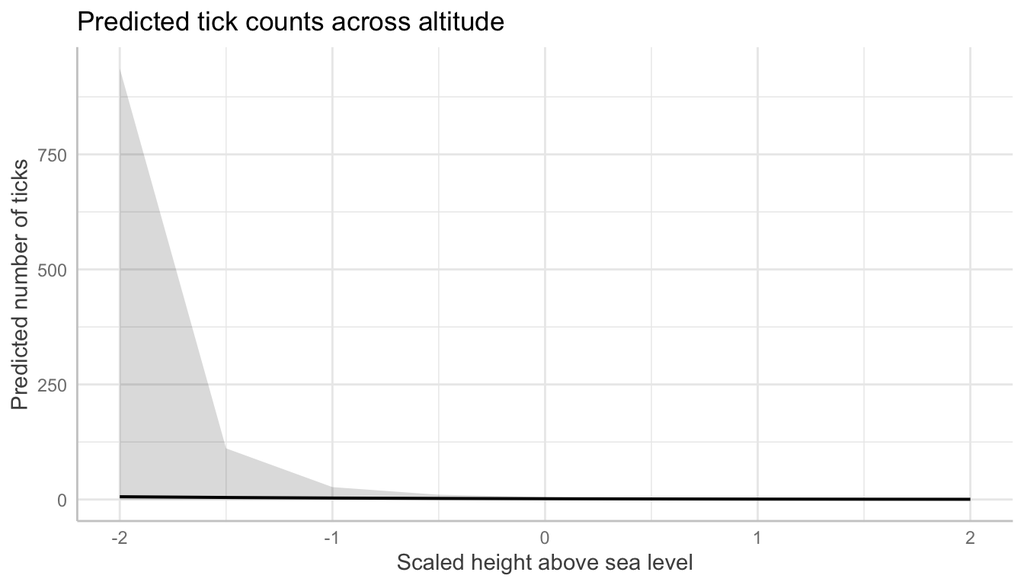

```r
ticks_pred <- ggpredict(ticks_glmm, terms = "height_scaled", type = "fixed")

plot(ticks_pred) +
  labs(
    title = "Predicted tick counts across altitude",
    x = "Scaled height above sea level",
    y = "Predicted number of ticks"
  )
```

## Check overdispersion

```r
overdisp_fun(ticks_glmm)
```

```
## # A tibble: 1 × 4
##   chisq ratio residual_df  p_value
##   <dbl> <dbl>       <int>    <dbl>
## 1  716.  2.13         337 1.79e-29
```

If the ratio is large, the Poisson assumption may be too restrictive.

## Optional: negative-binomial GLMM

A negative-binomial model allows the variance to be larger than the mean.

```r
ticks_nb <- glmmTMB::glmmTMB(
    TICKS ~ height_scaled + YEAR + LOCATION + (1 | BROOD),
    family = glmmTMB::nbinom2,
    data = ticks
  )

summary(ticks_nb)
```

```
##  Family: nbinom2  ( log )
## Formula:          TICKS ~ height_scaled + YEAR + LOCATION + (1 | BROOD)
## Data: ticks
##
##       AIC       BIC    logLik -2*log(L)  df.resid
##    1774.7    2042.6    -820.3    1640.7       336
##
## Random effects:
##
## Conditional model:
##  Groups Name        Variance Std.Dev.
##  BROOD  (Intercept) 0.05422  0.2329
## Number of obs: 403, groups:  BROOD, 118
##
## Dispersion parameter for nbinom2 family (): 3.19
##
## Conditional model:
##                 Estimate Std. Error z value Pr(>|z|)
## (Intercept)    6.064e-01  3.098e-01   1.957 0.050299 .
## height_scaled -6.288e-01  1.688e-01  -3.725 0.000195 ***
## YEAR96         1.099e+00  1.944e-01   5.651 1.60e-08 ***
## YEAR97        -1.163e+00  2.145e-01  -5.423 5.87e-08 ***
## LOCATION2     -9.665e-02  7.232e-01  -0.134 0.893677
## LOCATION3     -2.005e+00  5.167e-01  -3.880 0.000104 ***
## LOCATION4      1.079e+00  3.555e-01   3.035 0.002407 **
## LOCATION5      3.343e-01  5.140e-01   0.651 0.515352
## LOCATION6      9.293e-02  4.254e-01   0.218 0.827085
## LOCATION7      2.340e+00  4.324e-01   5.411 6.28e-08 ***
## LOCATION8     -2.188e-01  5.907e-01  -0.370 0.711104
## LOCATION9      1.002e+00  5.110e-01   1.960 0.049969 *
## LOCATION10    -3.151e-01  6.270e-01  -0.503 0.615307
## LOCATION11     9.637e-01  4.289e-01   2.247 0.024644 *
## LOCATION12    -9.677e-01  5.674e-01  -1.705 0.088108 .
## LOCATION13     1.784e-01  4.228e-01   0.422 0.673100
## LOCATION14    -3.131e-01  3.374e-01  -0.928 0.353384
## LOCATION15    -3.178e-01  6.052e-01  -0.525 0.599461
## LOCATION16     1.677e+00  5.630e-01   2.978 0.002900 **
## LOCATION17     2.529e-01  5.860e-01   0.432 0.666043
## LOCATION18    -4.976e-01  5.503e-01  -0.904 0.365860
## LOCATION19     5.142e-01  3.463e-01   1.485 0.137505
```

[output cut: 31 more lines]

```
## LOCATION51    -1.084e+00  6.646e-01  -1.631 0.102946
## LOCATION52    -2.671e+01  2.113e+05   0.000 0.999899
## LOCATION53     6.230e-01  5.511e-01   1.130 0.258316
## LOCATION54    -2.444e+01  1.093e+05   0.000 0.999822
## LOCATION55     6.206e-01  7.201e-01   0.862 0.388757
## LOCATION56    -3.180e-01  8.705e-01  -0.365 0.714882
## LOCATION57     5.788e-01  8.007e-01   0.723 0.469762
## LOCATION58    -1.662e+01  5.878e+03  -0.003 0.997744
## LOCATION59    -2.411e+01  9.950e+04   0.000 0.999807
## LOCATION60     1.281e+00  6.135e-01   2.088 0.036818 *
## LOCATION61    -6.902e-01  8.553e-01  -0.807 0.419707
## LOCATION62     6.429e-02  6.442e-01   0.100 0.920502
## LOCATION63            NA         NA      NA       NA
## ---
## Signif. codes:  0 '***' 0.001 '**' 0.01 '*' 0.05 '.' 0.1 ' ' 1
```

```r
# Compare Poisson GLMM and negative-binomial GLMM
AIC(ticks_glmm, ticks_nb)
```

```
##            df      AIC
## ticks_glmm 66 1971.566
## ticks_nb   67 1774.695
```

```r
overdisp_fun <- function(model) {
  rdf <- df.residual(model)
  pearson_resid <- residuals(model, type = "pearson")
  sum(pearson_resid^2) / rdf
}

overdisp_fun(ticks_glmm)
```

```
## [1] 2.125349
```

# Diagnostics and reporting

## Simulation-based residual diagnostics

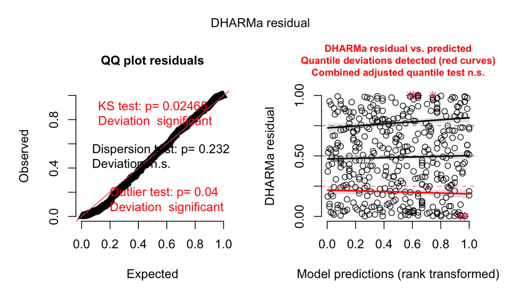

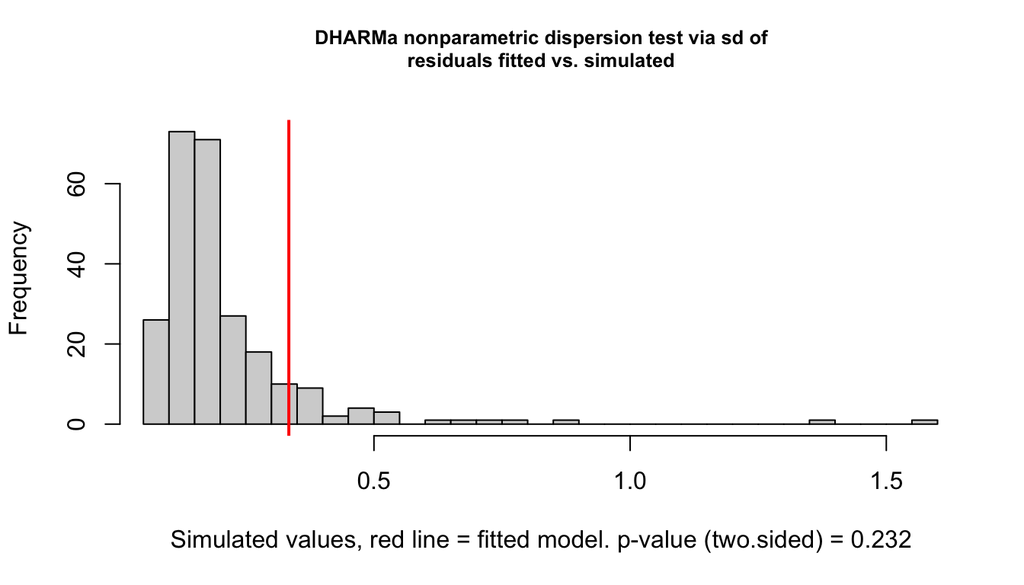

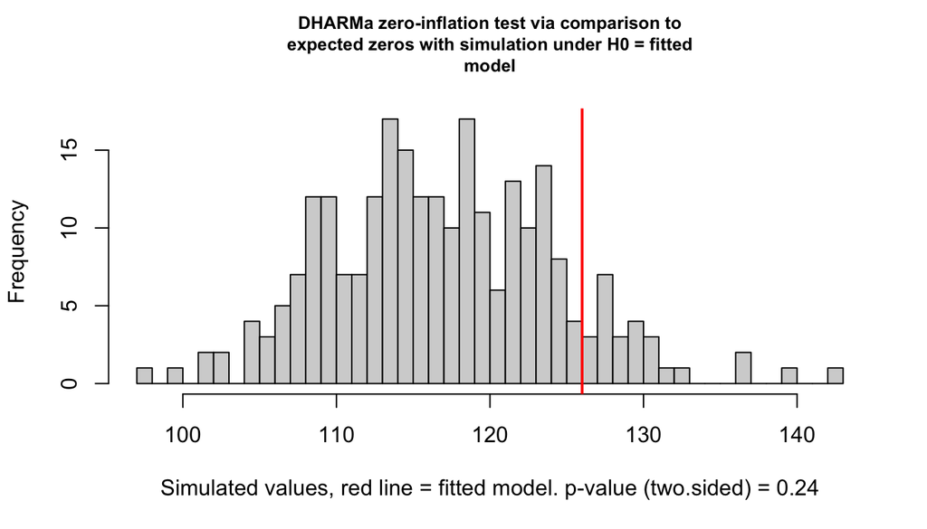

```
##
##  DHARMa zero-inflation test via comparison to expected zeros with
##  simulation under H0 = fitted model
##
## data:  simulationOutput
## ratioObsSim = 1.0735, p-value = 0.24
## alternative hypothesis: two.sided
```

```r
if (requireNamespace("DHARMa", quietly = TRUE)) {
  sim_res <- DHARMa::simulateResiduals(ticks_glmm)
  plot(sim_res)
  DHARMa::testDispersion(sim_res)
  DHARMa::testZeroInflation(sim_res)
}
```

These diagnostics can help detect:

- overdispersion;
- zero inflation;
- non-uniform residual patterns;
- outliers;
- mismatch between the response distribution and the data.

## Reporting template

A concise GLMM report should include:

1. the response distribution and link;
2. the fixed effects included;
3. the random-effect structure;
4. the grouping variable and number of groups;
5. how overdispersion and diagnostics were checked;
6. key estimates on a meaningful scale;
7. uncertainty intervals or confidence intervals;
8. a plot of predicted values.

Example wording:

> We fitted a Poisson GLMM with a log link to model tick counts. Height, year and location were included as fixed effects, and brood was included as a random intercept to account for non-independence among chicks from the same brood. Coefficients were interpreted as multiplicative effects after exponentiation. We assessed overdispersion using Pearson residuals and inspected simulation-based residual diagnostics.

# Final exercise

## Practical exercise: build your own GLMM workflow

Choose either the disease incidence data or the tick count data.

1. State the response distribution and link function.
2. Identify the grouping variable.
3. Fit a GLMM with one or more fixed effects.
4. Plot predictions on the response scale.
5. Check overdispersion.
6. Write a short interpretation of the main fixed effect.

## Interpretation checklist

Before interpreting a GLMM, ask:

- What scale are the coefficients on?
- What scale are the predictions on?
- Is there evidence of important group-level variation?
- Is the response distribution plausible?
- Are there signs of overdispersion or zero inflation?
- Would a simpler model answer the research question?

## Key take-home messages

- GLMMs are useful when responses are non-Gaussian and observations are grouped.
- The distribution and link function should match the response type.
- Random effects account for grouping and enable partial pooling.
- Interpretation is easiest using predictions on the response scale.
- Overdispersion is not just a diagnostic number: it is a clue that the model may be missing important structure.